# Test of Analyzing Financial Data

Yuhang Fan

```python
import pandas as pd
import numpy as np
import matplotlib.pyplot as plt
%matplotlib inline
```

### Q6. Provide a working implementation for calculating MVP using the programming language of your choice

```python
import yfinance as yf
```

#### Get stock data from Yahoo Finance

```python
start_date = '2015-01-01'
end_date = '2022-01-01'

tickers_list = ['AAPL', 'NKE', 'GOOGL', 'NVDA']

data = pd.DataFrame(columns=tickers_list)

for ticker in tickers_list:
    data[ticker] = yf.download(ticker,
                               start_date,
                               end_date)['Adj Close']
data.tail()
```

```
[*********************100%***********************]  1 of 1 completed
[*********************100%***********************]  1 of 1 completed
[*********************100%***********************]  1 of 1 completed
[*********************100%***********************]  1 of 1 completed
```

| Date | AAPL | NKE | GOOGL | NVDA |
| --- | --- | --- | --- | --- |
| 2021-12-27 | 180.100540 | 167.580002 | 2958.129883 | 309.450012 |
| 2021-12-28 | 179.061859 | 166.419998 | 2933.739990 | 303.220001 |
| 2021-12-29 | 179.151749 | 168.779999 | 2933.100098 | 300.010010 |
| 2021-12-30 | 177.973251 | 167.490005 | 2924.010010 | 295.859985 |
| 2021-12-31 | 177.344055 | 166.669998 | 2897.040039 | 294.109985 |

```python
ret_df = data.pct_change()
ret_df.head()
```

| Date | AAPL | NKE | GOOGL | NVDA |
| --- | --- | --- | --- | --- |
| 2015-01-02 | NaN | NaN | NaN | NaN |
| 2015-01-05 | -0.028172 | -0.016100 | -0.019054 | -0.016890 |
| 2015-01-06 | 0.000094 | -0.005882 | -0.024679 | -0.030318 |
| 2015-01-07 | 0.014022 | 0.020657 | -0.002941 | -0.002605 |
| 2015-01-08 | 0.038422 | 0.023084 | 0.003484 | 0.037617 |

#### Annualized covariance matrix

```python
var_matrix = ret_df.cov()*252
var_matrix
```

|  | AAPL | NKE | GOOGL | NVDA |
| --- | --- | --- | --- | --- |
| AAPL | 0.084222 | 0.034451 | 0.046057 | 0.070909 |
| NKE | 0.034451 | 0.075496 | 0.032157 | 0.047648 |
| GOOGL | 0.046057 | 0.032157 | 0.069968 | 0.061837 |
| NVDA | 0.070909 | 0.047648 | 0.061837 | 0.206945 |

#### Return matrix

```python
return_stock = []
for stock in tickers_list:
    return_stock.append(ret_df[stock].mean()*252)
return_stock
```

```
[0.32414247560161197,
 0.22763516411531404,
 0.27798153089537736,
 0.6906428865816379]
```

#### Generate different weights and record portfolio return and std

```python
return_ = []
weight_ = []
std_ = []
asset_num = len(tickers_list)
for i in range(10000):
    # Generate random weight with sum equal to one
    weight = np.random.random(asset_num)
    weight = weight/np.sum(weight)
    weight_.append(weight)
    # Calculate portfolio std
    std = np.sqrt(np.dot(weight.T, np.dot(var_matrix,weight)))
    std_.append(std)
    # Calculate portfolio return
    port_return = np.dot(return_stock, weight)
    return_.append(port_return)
```

```python
risk_free = 0.05
```

```python
output = pd.DataFrame({'weight' : weight_ , 'return' : return_, 'stdev' :std_ })
output['sharpe'] = (output['return'] - risk_free) / output['stdev']
output.head()
```

|  | weight | return | stdev | sharpe |
| --- | --- | --- | --- | --- |
| 0 | [0.3696774355068973, 0.0711571925086095, 0.269... | 0.410809 | 0.270777 | 1.332497 |
| 1 | [0.1562531508261752, 0.12658219489359646, 0.41... | 0.405415 | 0.266842 | 1.331929 |
| 2 | [0.5272713844876749, 0.2572935945912677, 0.027... | 0.366729 | 0.257240 | 1.231258 |
| 3 | [0.23560605065915993, 0.31685676143599806, 0.2... | 0.351263 | 0.241818 | 1.245823 |
| 4 | [0.4056402071414736, 0.1941161201784563, 0.256... | 0.346422 | 0.243534 | 1.217170 |

#### Get the weight vector which minimize the volatility of the portfolio or maximize the sharpe ratio

```python
maxsharpe_pos = output.iloc[output.sharpe.idxmax(),:]
minstd_pos = output.iloc[output.stdev.idxmin(),:]
```

#### Visualize the result

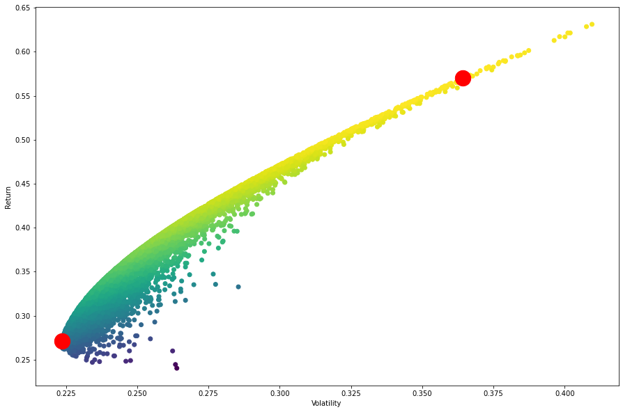

```python
plt.subplots(figsize=(15,10))
plt.scatter(output.stdev,output['return'],c=output.sharpe)
plt.xlabel('Volatility')
plt.ylabel('Return')

plt.scatter(maxsharpe_pos.stdev,maxsharpe_pos['return'],marker='o',color='r',s=500)
plt.scatter(minstd_pos.stdev,minstd_pos['return'],marker='o',color='r',s=500)
```

```python
print("The Minimun volatility porfolio is at {} volitality".format(minstd_pos.stdev.round(3)))

for i in range(len(tickers_list)):
    print("{} : {}%".format(tickers_list[i],(minstd_pos.weight[i] * 100).round(3)))
```

```
The Minimun volatility porfolio is at 0.224 volitality
AAPL : 20.207%
NKE : 38.229%
GOOGL : 40.763%
NVDA : 0.8%
```

### Q7. Provide a working implementation using the programming language of your choice. (Minimum Tracking Error Portfolio)

#### Get the benchmark data

```python
BM_ticker = 'SPY'

data_BM = pd.DataFrame(columns=[BM_ticker])

data_BM[BM_ticker] = yf.download(BM_ticker,
                           start_date,
                           end_date)['Adj Close']
data_BM.tail()
```

```
[*********************100%***********************]  1 of 1 completed
```

| Date | SPY |
| --- | --- |
| 2021-12-27 | 477.260010 |
| 2021-12-28 | 476.869995 |
| 2021-12-29 | 477.480011 |
| 2021-12-30 | 476.160004 |
| 2021-12-31 | 474.959991 |

```python
ret_BM_df = data_BM.pct_change()
ret_BM_df.head()
```

| Date | SPY |
| --- | --- |
| 2015-01-02 | NaN |
| 2015-01-05 | -0.018060 |
| 2015-01-06 | -0.009419 |
| 2015-01-07 | 0.012461 |
| 2015-01-08 | 0.017745 |

#### Std of benchmark

```python
BM_std = ret_BM_df[BM_ticker].std()*np.sqrt(252)
```

#### Generate different weights and record portfolio return and Tracking Error

```python
return_ = []
weight_ = []
TE_ = []
for i in range(10000):
    # Generate random weight with sum equal to one
    weight = np.random.random(asset_num)
    weight = weight/np.sum(weight)
    weight_.append(weight)
    # Calculate portfolio std
    port_std = np.sqrt(np.dot(weight.T, np.dot(var_matrix,weight)))
    # Calculate portfolio return
    port_return = np.dot(return_stock, weight)
    return_.append(port_return)
    # Calculate the correlation between portfolio and benchmark
    portfolio_ret_se = ret_df.dot(weight)
    corr_p_BM = ret_BM_df[BM_ticker].corr(portfolio_ret_se)
    # Calculate tracking error
    TE = np.sqrt(port_std**2+BM_std**2-2*corr_p_BM*port_std*BM_std)
    TE_.append(TE)
```

```python
output_TE = pd.DataFrame({'weight' : weight_ , 'return' : return_, 'Tracking_error' :TE_})
output_TE.head()
```

|  | weight | return | Tracking_error |
| --- | --- | --- | --- |
| 0 | [0.2608838845877179, 0.17483259067605472, 0.42... | 0.337569 | 0.126772 |
| 1 | [0.32195765629174944, 0.24919736277554885, 0.1... | 0.392523 | 0.148697 |
| 2 | [0.30686384000703976, 0.33529757258647896, 0.1... | 0.363222 | 0.136555 |
| 3 | [0.24951985152963135, 0.23972191602777349, 0.2... | 0.379706 | 0.140711 |
| 4 | [0.43111681320045186, 0.11227894601988953, 0.0... | 0.479257 | 0.208201 |

#### Get the weight vector which minimize the Tracking Error

```python
minTE_pos = output_TE.iloc[output_TE.Tracking_error.idxmin(),:]
```

#### Visualize the result

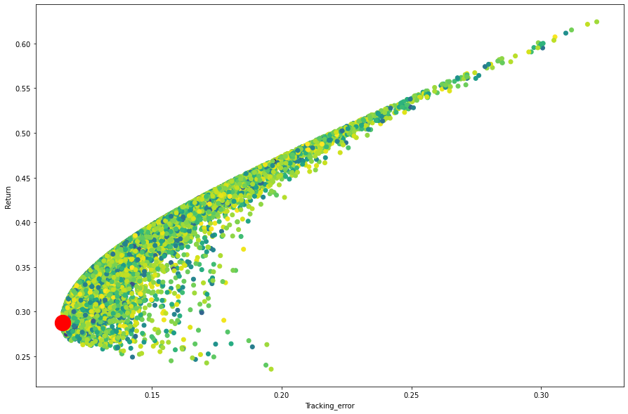

```python
plt.subplots(figsize=(15,10))
plt.scatter(output_TE.Tracking_error,output_TE['return'],c=output.sharpe)
plt.xlabel('Tracking_error')
plt.ylabel('Return')

plt.scatter(minTE_pos.Tracking_error,minTE_pos['return'],marker='o',color='r',s=500)
```

```python
print("The Minimun Tracking Error porfolio is at {} Tracking Error".format(minTE_pos.Tracking_error.round(3)))

for i in range(len(tickers_list)):
    print("{} : {}%".format(tickers_list[i],(minTE_pos.weight[i] * 100).round(3)))
```

```
The Minimun Tracking Error porfolio is at 0.116 Tracking Error
AAPL : 27.753%
NKE : 33.222%
GOOGL : 35.641%
NVDA : 3.384%
```

### Q8. What is the connection between the minimum TE portfolio procedure you derived above and this linear regression procedure? Describe the similarities and differences. Under what scenarios will one be better than the other? Use both mathematics and intuitive reasoning to narrate the answer.

- Minimum TE portfolio procedure and linear regression procedure both applying same idea that minimize the difference of portfolio return and benchmark return
- Minimum TE portfolio procedure use variance of return difference as metric
- Linear regression procedure use mean square of return difference as metric
- According to the metric formulas of both procedures,the major difference is that Minimum TE portfolio takes into account the correlation between assests in portfolio
- Thus, when the portfolio contain highly correlated assets, Minimum TE portfolio procedure is better than inear regression procedure

### Q9. Please use the ‘Fund Level Data’ sheet to answer the questions below

```python
xls = pd.ExcelFile('position_trade.xlsx')
Fund_data = pd.read_excel(xls, 'Fund Level Data')
```

```python
Fund_data.head()
```

|  | date | net_asset_value | cash_transfer |
| --- | --- | --- | --- |
| 0 | 2014-05-31 | 4.992127e+07 | 0 |
| 1 | 2014-06-02 | 5.007563e+07 | 0 |
| 2 | 2014-06-03 | 5.004748e+07 | 0 |
| 3 | 2014-06-04 | 5.018828e+07 | 0 |
| 4 | 2014-06-05 | 5.050317e+07 | 0 |

#### (a) Calculate the following portfolio stats

- Total return in %

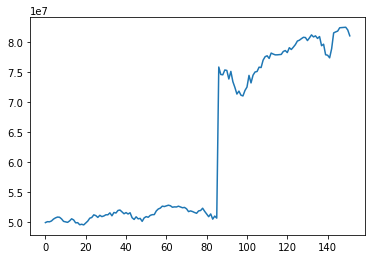

```python
# Take a look at data and plot first
Fund_data.net_asset_value.plot()
```

```python
Fund_data[Fund_data.cash_transfer!=0]
```

|  | date | net_asset_value | cash_transfer |
| --- | --- | --- | --- |
| 86 | 2014-09-30 | 75865164.38 | 25000000 |

```python
ret = 100*(Fund_data['net_asset_value'].iloc[-1]-Fund_data['net_asset_value'].iloc[0]- sum(Fund_data['cash_transfer']))/Fund_data['net_asset_value'].iloc[0]
print("Total return in % is {c:.2f}".format(c = ret))
```

```
Total return in % is 12.31
```

- Total P&L

```python
total_P_L = Fund_data['net_asset_value'].iloc[-1]-Fund_data['net_asset_value'].iloc[0]- sum(Fund_data['cash_transfer'])
print("Total P&L is {p:.2f}".format(p=total_P_L))
```

```
Total P&L is 6146112.22
```

- Annualized Sharpe ratio

```python
Fund_data['portfolio_change'] = Fund_data['net_asset_value']-Fund_data['cash_transfer'].cumsum()
```

```python
Fund_data['return'] = Fund_data['portfolio_change'].pct_change()
Fund_data['return_plus_1'] = Fund_data['return'] + 1
Fund_data['cum_return'] = Fund_data['return_plus_1'].cumprod()
```

```python
Fund_data.head()
```

|  | date | net_asset_value | cash_transfer | portfolio_change | return | return_plus_1 | cum_return |
| --- | --- | --- | --- | --- | --- | --- | --- |
| 0 | 2014-05-31 | 4.992127e+07 | 0 | 4.992127e+07 | NaN | NaN | NaN |
| 1 | 2014-06-02 | 5.007563e+07 | 0 | 5.007563e+07 | 0.003092 | 1.003092 | 1.003092 |
| 2 | 2014-06-03 | 5.004748e+07 | 0 | 5.004748e+07 | -0.000562 | 0.999438 | 1.002528 |
| 3 | 2014-06-04 | 5.018828e+07 | 0 | 5.018828e+07 | 0.002813 | 1.002813 | 1.005349 |
| 4 | 2014-06-05 | 5.050317e+07 | 0 | 5.050317e+07 | 0.006274 | 1.006274 | 1.011656 |

```python
sharpe_ratio_daily = Fund_data['return'].mean()/Fund_data['return'].std()
sharpe_ratio_annual = sharpe_ratio_daily*252**0.5
print("Annualized Sharpe ratio is {s:.2f}".format(s=sharpe_ratio_annual))
```

```
Annualized Sharpe ratio is 1.16
```

- Simple annualized return in bps

```python
ret
```

```
12.311610846612288
```

```python
s_annual_ret = (1+ret/100)**(252/len(Fund_data))-1
print("Simple annualized return in bps is {k:.0f}".format(k = s_annual_ret/0.0001))
```

```
Simple annualized return in bps is 2123
```

#### (b) Generate charts to show

- Compounding cumulative return

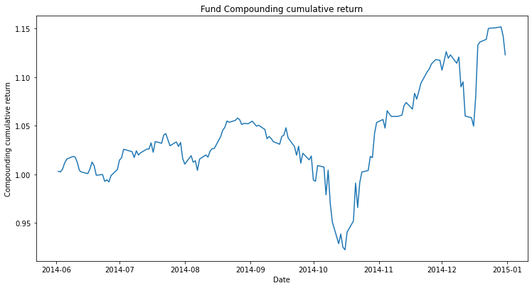

```python
fig = plt.figure(figsize=(12, 6))
ax1 = fig.add_axes([1,2,0.8,0.8])
ax1.plot(Fund_data[['date','cum_return']].set_index('date'))
ax1.set_xlabel('Date')
ax1.set_ylabel("Compounding cumulative return")
ax1.set_title("Fund Compounding cumulative return")
plt.show()
```

- Net asset value and cash transfer over time

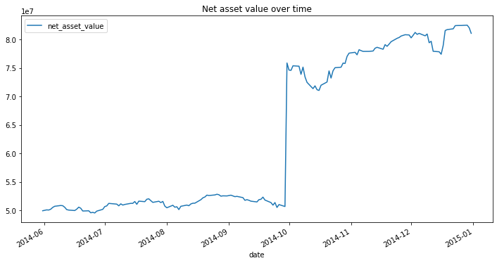

```python
Fund_data[['date','net_asset_value']].set_index('date').plot(figsize=(12,6),title='Net asset value over time')
```

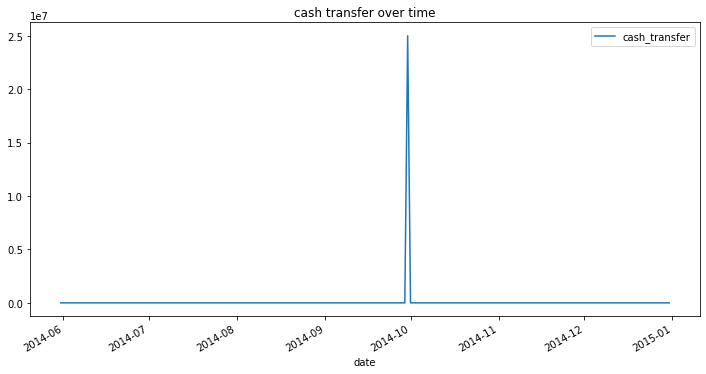

```python
Fund_data[['date','cash_transfer']].set_index('date').plot(figsize=(12,6),title='cash transfer over time')
```

Do you spot any bad data or abnormal behavior? If so, can you fix the problem or explain the discrepancy?

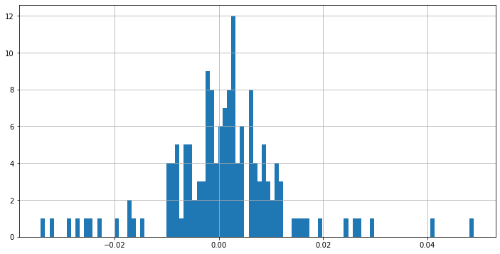

```python
fig, ax = plt.subplots()
Fund_data['return'].hist(bins=100, ax=ax, figsize=(12,6))
```

- No bad data is found

### Q10. Please use the ‘Fund Level Data’ and ‘Holdings Data’ sheets to answer the questions below

```python
Holding_data = pd.read_excel(xls, 'Holdings Data')
```

```python
Holding_data.head()
```

|  | date | asset_id | asset_type_id | quantity | local_price | local_currency_id | base_currency_id | base_market_value |
| --- | --- | --- | --- | --- | --- | --- | --- | --- |
| 0 | 2014-05-31 | 176 | 1 | 9680 | 633.00 | 1 | 1 | 6127440.0 |
| 1 | 2014-05-31 | 205 | 1 | 46500 | 80.45 | 1 | 1 | 3740925.0 |
| 2 | 2014-05-31 | 206 | 1 | 165500 | 42.02 | 1 | 1 | 6954310.0 |
| 3 | 2014-05-31 | 246 | 1 | 35500 | 84.01 | 1 | 1 | 2982355.0 |
| 4 | 2014-05-31 | 299 | 1 | 101000 | 34.56 | 1 | 1 | 3490560.0 |

#### (a) Calculate the following portfolio stats

- Range of position counts

```python
position_c_max = Holding_data.groupby('date')['asset_id'].count().max()
position_c_min = Holding_data.groupby('date')['asset_id'].count().min()
print("Range of position counts is ({},{})".format(position_c_min,position_c_max))
```

```
Range of position counts is (12,14)
```

- Range of position weights

```python
Holding_data = Holding_data.merge(Holding_data.groupby('date').apply(lambda x:x['base_market_value'].sum()).rename('total_base_market_value'),on='date')
```

```python
Holding_data['weights'] = Holding_data['base_market_value']/Holding_data['total_base_market_value']
```

```python
Holding_data.head()
```

|  | date | asset_id | asset_type_id | quantity | local_price | local_currency_id | base_currency_id | base_market_value | total_base_market_value | weights |
| --- | --- | --- | --- | --- | --- | --- | --- | --- | --- | --- |
| 0 | 2014-05-31 | 176 | 1 | 9680 | 633.00 | 1 | 1 | 6127440.0 | 49610226.0 | 0.123512 |
| 1 | 2014-05-31 | 205 | 1 | 46500 | 80.45 | 1 | 1 | 3740925.0 | 49610226.0 | 0.075406 |
| 2 | 2014-05-31 | 206 | 1 | 165500 | 42.02 | 1 | 1 | 6954310.0 | 49610226.0 | 0.140179 |
| 3 | 2014-05-31 | 246 | 1 | 35500 | 84.01 | 1 | 1 | 2982355.0 | 49610226.0 | 0.060116 |
| 4 | 2014-05-31 | 299 | 1 | 101000 | 34.56 | 1 | 1 | 3490560.0 | 49610226.0 | 0.070360 |

```python
position_w_max = Holding_data['weights'].max()
position_w_min = Holding_data['weights'].min()
print("Range of position weights is ({a:.4f},{b:.4f})".format(a=position_w_min,b=position_w_max))
```

```
Range of position weights is (0.0034,0.1635)
```

- Range of fund total exposure

```python
exposure_df = Fund_data[['date','net_asset_value']].set_index('date').merge(Holding_data.groupby('date').apply(lambda x:x['base_market_value'].sum()).rename('total_base_market_value'),on='date')
```

```python
exposure_df.head()
```

| date | net_asset_value | total_base_market_value |
| --- | --- | --- |
| 2014-05-31 | 4.992127e+07 | 4.961023e+07 |
| 2014-06-02 | 5.007563e+07 | 4.974506e+07 |
| 2014-06-03 | 5.004748e+07 | 4.971690e+07 |
| 2014-06-04 | 5.018828e+07 | 4.982011e+07 |
| 2014-06-05 | 5.050317e+07 | 5.013500e+07 |

```python
exp_min = exposure_df['total_base_market_value'].min()
exp_max = exposure_df['total_base_market_value'].max()
print("Range of fund total exposure is ({m:.2f},{n:.2f})".format(m=exp_min,n=exp_max))
```

```
Range of fund total exposure is (47368705.10,79154159.40)
```

#### (b) Generate charts to show

- Position counts over time

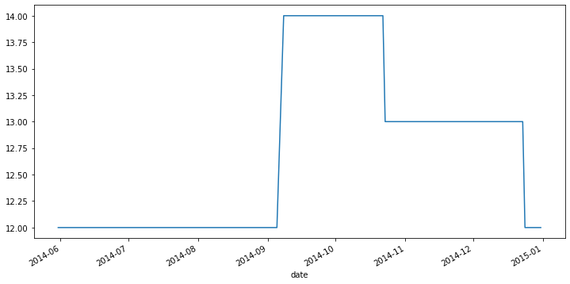

```python
Holding_data.groupby('date')['asset_id'].count().plot(figsize=(12,6))
```

- Position weights distribution

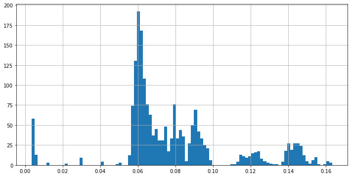

```python
Holding_data['weights'].hist(bins=100,figsize=(12,6))
```

- Fund total exposure over time

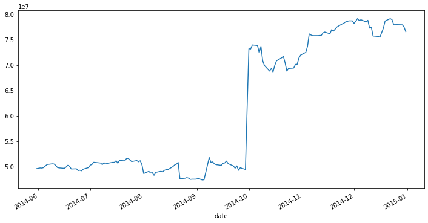

```python
exposure_df['total_base_market_value'].plot(figsize=(12,6))
```

Do you spot any bad data or abnormal behavior? If so, can you fix the problem or explain the discrepancy?

### Q11. Please use the ‘Holdings Data’ and ‘Trades Data’ sheets to answer the questions below

```python
Trade_data = pd.read_excel(xls, 'Trades Data')
Trade_data.head()
```

|  | date | asset_id | trade_type_id | trade_quantity | local_price | base_cash_movement | transaction_id |
| --- | --- | --- | --- | --- | --- | --- | --- |
| 0 | 2014-06-02 | 205 | 3 | 46500 | 0.0000 | 19530.00 | 235366655 |
| 1 | 2014-06-06 | 386 | 1 | 3708 | 49.6210 | -183994.67 | 800771455 |
| 2 | 2014-06-06 | 801 | 2 | -1152 | 88.3018 | 101723.67 | 600771455 |
| 3 | 2014-06-09 | 176 | 5 | 58080 | 0.0000 | 0.00 | 835131455 |
| 4 | 2014-06-20 | 176 | 2 | -5569 | 92.0327 | 512530.11 | 401460655 |

#### (a) Do the quantities reconcile between the two sheets? If not, can you fix the problem or explain the discrepancy?

```python
# Asset which are traded in trade data sheet
set(Trade_data['asset_id'].to_list())
```

```
{176, 205, 206, 246, 284, 299, 370, 386, 515, 542, 753, 801, 1050, 8716}
```

```python
traded_li = list(set(Trade_data['asset_id'].to_list()))
```

```python
Trade_data.loc[Trade_data.trade_type_id!=3 ,'actual_traded_quant'] = Trade_data.trade_quantity
Trade_data.loc[Trade_data.trade_type_id==3,'actual_traded_quant'] = 0
```

```python
Trade_data.head()
```

|  | date | asset_id | trade_type_id | trade_quantity | local_price | base_cash_movement | transaction_id | actual_traded_quant |
| --- | --- | --- | --- | --- | --- | --- | --- | --- |
| 0 | 2014-06-02 | 205 | 3 | 46500 | 0.0000 | 19530.00 | 235366655 | 0.0 |
| 1 | 2014-06-06 | 386 | 1 | 3708 | 49.6210 | -183994.67 | 800771455 | 3708.0 |
| 2 | 2014-06-06 | 801 | 2 | -1152 | 88.3018 | 101723.67 | 600771455 | -1152.0 |
| 3 | 2014-06-09 | 176 | 5 | 58080 | 0.0000 | 0.00 | 835131455 | 58080.0 |
| 4 | 2014-06-20 | 176 | 2 | -5569 | 92.0327 | 512530.11 | 401460655 | -5569.0 |

```python
# Function which can tell if the quantity matches between two sheets
def quantities_analyzer(asset_id,trade_data,holding_data):
    df_1 = trade_data.loc[trade_data.asset_id==asset_id,['date','actual_traded_quant','transaction_id']]
    df_2 = holding_data.loc[holding_data.asset_id == asset_id, ['date','quantity']]
    df_1.drop_duplicates(subset=['transaction_id'],inplace=True) # There are some duplicate data in Trade Data sheet
    dff= df_2.merge(df_1,how='outer').fillna(0)
    dff['actual_traded_quant'] = dff['actual_traded_quant'].cumsum()
    # Already having position in this asset
    bool_1 = dff['quantity'].values[0] + dff['actual_traded_quant'].values[-1] == dff['quantity'].values[-1]
    # Not having any position in this asset
    bool_2 = dff['actual_traded_quant'].values[-1] == dff['quantity'].values[-1]
    return bool_1 or bool_2
```

```python
for asset_id in traded_li:
    if quantities_analyzer(asset_id,Trade_data,Holding_data) == False:
        print("The quantities does not reconcile in asset {}".foramt(asset_id))
print("The quantities reconcile between the two sheets")
```

```
The quantities reconcile between the two sheets
```

- I find some duplicate tansaction data in Trade Data sheet and I use 'drop_duplicates' method to drop them

#### (b) Do the trade prices reconcile between the two sheets? If not, can you fix the problem or explain the discrepancy?

```python
price_df = Trade_data[['date','asset_id','local_price']].merge(Holding_data[['date','asset_id','local_price']],on=['date','asset_id'])
```

```python
price_df.head()
```

|  | date | asset_id | local_price_x | local_price_y |
| --- | --- | --- | --- | --- |
| 0 | 2014-06-02 | 205 | 0.0000 | 80.479996 |
| 1 | 2014-06-06 | 386 | 49.6210 | 49.699997 |
| 2 | 2014-06-06 | 801 | 88.3018 | 88.299988 |
| 3 | 2014-06-09 | 176 | 0.0000 | 93.699997 |
| 4 | 2014-06-20 | 176 | 92.0327 | 90.909989 |

- It is shown above the trade prices does not reconcile between the two sheets
- That is because in Holding Data sheet the price is the daily close price
- But in Trades Data sheet, local price is the price when transaction executed
- The prices are recorded in different time

And when the trade type id is 3 or 5, the local price becomes 0 for all asset  
To solve this problem, we can replace 0 by the local price in Holdings Data sheet

```python
price_df.loc[price_df.local_price_x==0,'local_price_x'] = price_df.local_price_y
```

```python
price_df.head()
```

|  | date | asset_id | local_price_x | local_price_y |
| --- | --- | --- | --- | --- |
| 0 | 2014-06-02 | 205 | 80.479996 | 80.479996 |
| 1 | 2014-06-06 | 386 | 49.621000 | 49.699997 |
| 2 | 2014-06-06 | 801 | 88.301800 | 88.299988 |
| 3 | 2014-06-09 | 176 | 93.699997 | 93.699997 |
| 4 | 2014-06-20 | 176 | 92.032700 | 90.909989 |

### Q12. Please use the ‘Holdings Data’ and ‘Trades Data’ sheets to answer the questions below

```python
Holding_data.head()
```

|  | date | asset_id | asset_type_id | quantity | local_price | local_currency_id | base_currency_id | base_market_value | total_base_market_value | weights |
| --- | --- | --- | --- | --- | --- | --- | --- | --- | --- | --- |
| 0 | 2014-05-31 | 176 | 1 | 9680 | 633.00 | 1 | 1 | 6127440.0 | 49610226.0 | 0.123512 |
| 1 | 2014-05-31 | 205 | 1 | 46500 | 80.45 | 1 | 1 | 3740925.0 | 49610226.0 | 0.075406 |
| 2 | 2014-05-31 | 206 | 1 | 165500 | 42.02 | 1 | 1 | 6954310.0 | 49610226.0 | 0.140179 |
| 3 | 2014-05-31 | 246 | 1 | 35500 | 84.01 | 1 | 1 | 2982355.0 | 49610226.0 | 0.060116 |
| 4 | 2014-05-31 | 299 | 1 | 101000 | 34.56 | 1 | 1 | 3490560.0 | 49610226.0 | 0.070360 |

```python
Trade_data.head()
```

|  | date | asset_id | trade_type_id | trade_quantity | local_price | base_cash_movement | transaction_id | actual_traded_quant |
| --- | --- | --- | --- | --- | --- | --- | --- | --- |
| 0 | 2014-06-02 | 205 | 3 | 46500 | 0.0000 | 19530.00 | 235366655 | 0.0 |
| 1 | 2014-06-06 | 386 | 1 | 3708 | 49.6210 | -183994.67 | 800771455 | 3708.0 |
| 2 | 2014-06-06 | 801 | 2 | -1152 | 88.3018 | 101723.67 | 600771455 | -1152.0 |
| 3 | 2014-06-09 | 176 | 5 | 58080 | 0.0000 | 0.00 | 835131455 | 58080.0 |
| 4 | 2014-06-20 | 176 | 2 | -5569 | 92.0327 | 512530.11 | 401460655 | -5569.0 |

#### (a) Calculate the following portfolio stats

- Total return in %

```python
portfolio_ret = (Holding_data['total_base_market_value'].values[-1]-Holding_data['total_base_market_value'].values[0]+Trade_data.drop_duplicates()['base_cash_movement'].sum())/Holding_data['total_base_market_value'].values[0]
print("Total return of portfolio in % is {r:.2f}".format(r=portfolio_ret*100))
```

```
Total return of portfolio in % is 12.52
```

- Total P&L

```python
portfolio_P_L = Holding_data['total_base_market_value'].values[-1]-Holding_data['total_base_market_value'].values[0]+Trade_data['base_cash_movement'].sum()
print("Total  P&L of portfolio is {p:.2f}".format(p=portfolio_P_L))
```

```
Total  P&L of portfolio is 4598271.37
```

- Annualized Sharpe ratio

```python
df_1 = Holding_data.groupby('date').apply(lambda x:x['base_market_value'].sum()).reset_index(name='base_market_value_sum')
```

```python
df_2 = Trade_data.drop_duplicates().groupby('date').apply(lambda x:x['base_cash_movement'].sum()).cumsum().reset_index(name='base_cash_movement_sum')
```

```python
df_3 = df_1.merge(df_2,how='outer').fillna(method='ffill').fillna(0)
```

```python
df_3['total_sum'] = df_3['base_market_value_sum'] + df_3['base_cash_movement_sum']
df_3['ret'] = df_3['total_sum'].pct_change()
```

```python
df_3.head()
```

|  | date | base_market_value_sum | base_cash_movement_sum | total_sum | ret |
| --- | --- | --- | --- | --- | --- |
| 0 | 2014-05-31 | 4.961023e+07 | 0.0 | 4.961023e+07 | NaN |
| 1 | 2014-06-02 | 4.974506e+07 | 19530.0 | 4.976459e+07 | 0.003112 |
| 2 | 2014-06-03 | 4.971690e+07 | 19530.0 | 4.973643e+07 | -0.000566 |
| 3 | 2014-06-04 | 4.982011e+07 | 19530.0 | 4.983964e+07 | 0.002075 |
| 4 | 2014-06-05 | 5.013500e+07 | 19530.0 | 5.015453e+07 | 0.006318 |

```python
portfolio_SR = df_3['ret'].mean()/df_3['ret'].std()
annual_portfolio_SR = portfolio_SR*252**0.5
print("Annualized portfolio Sharpe ratio is {s:.2f}".format(s=annual_portfolio_SR))
```

```
Annualized portfolio Sharpe ratio is 1.17
```

- Simple annualized return in bps

```python
holding_period = len(set(Fund_data['date']))
```

```python
portfolio_annual_ret = (1+portfolio_ret)**(252/holding_period)-1
print("Simple annualized portfoilo return in bps is {k:.0f}".format(k = portfolio_annual_ret/0.0001))
```

```
Simple annualized portfoilo return in bps is 2160
```

#### (b) Generate charts to show

- Compounding cumulative return from trade P&L and compare with the one calculated from Q9

```python
df_3['cum_ret_portfolio'] = (df_3['ret']+1).cumprod()
```

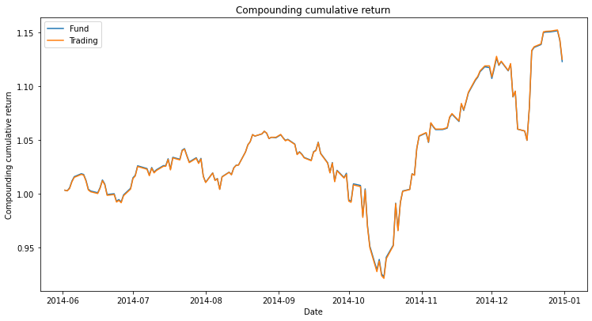

```python
fig = plt.figure(figsize=(12, 6))
ax1 = fig.add_axes([1,2,0.8,0.8])
ax1.plot(Fund_data[['date','cum_return']].set_index('date'),label='Fund')
ax1.plot(df_3[['date','cum_ret_portfolio']].set_index('date'),label='Trading')
ax1.set_xlabel('Date')
ax1.set_ylabel("Compounding cumulative return")
ax1.set_title("Compounding cumulative return")
plt.legend()
plt.show()
```

- Number of trades over time

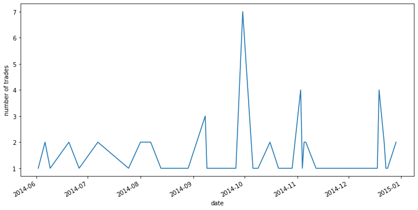

```python
Trade_data.groupby('date').apply(lambda x:len(x)).plot(ylabel='number of trades',figsize=(12,6))
```

```python
print('Done')
```

```
Done
```